# Analysis of an ambient air pollutant across the US

Mariia Danilenko

# Introduction

Fine particulate matter (PM2.5) is an ambient air pollutant for which there is strong evidence that it is harmful to human health. In the United States, the Environmental Protection Agency (EPA) is tasked with setting national ambient air quality standards for fine PM and for tracking the emissions of this pollutant into the atmosphere. Approximatly every 3 years, the EPA releases its database on emissions of PM2.5. This database is known as the National Emissions Inventory (NEI). You can read more information about the NEI at the EPA National Emissions Inventory web site.

For each year and for each type of PM source, the NEI records how many tons of PM2.5 were emitted from that source over the course of the entire year. The data that you will use for this assignment are for 1999, 2002, 2005, and 2008. # Questions  
1. Have total emissions from PM2.5 decreased in the United States from 1999 to 2008?  
2. Have total emissions from PM2.5 decreased in the Baltimore City, Maryland (fips == “24510”) from 1999 to 2008? 3. Of the four types of sources indicated by the type (point, nonpoint, onroad, nonroad) variable, which of these four sources have seen decreases in emissions from 1999–2008 for Baltimore City? Which have seen increases in emissions from 1999–2008?  
4. Across the United States, how have emissions from coal combustion-related sources changed from 1999–2008?  
5. How have emissions from motor vehicle sources changed from 1999–2008 in Baltimore City?  
6. Compare emissions from motor vehicle sources in Baltimore City with emissions from motor vehicle sources in Los Angeles County, California (fips == “06037”). Which city has seen greater changes over time in motor vehicle emissions? # Analysis  
## Data processing  
Download data with the given link:

```r
url <- "https://d396qusza40orc.cloudfront.net/exdata%2Fdata%2FNEI_data.zip"
download.file(url, "AirData.zip")
unzip("AirData.zip", exdir="AirData")
files <- list.files("AirData")
filename1 <- paste("./AirData/",files[1],sep="")
filename2 <- paste("./AirData/",files[2],sep="")
data1 <- readRDS(filename1)
head(data1)
```

```
##        SCC Data.Category
## 1 10100101         Point
## 2 10100102         Point
## 3 10100201         Point
## 4 10100202         Point
## 5 10100203         Point
## 6 10100204         Point
##                                                                   Short.Name
## 1                   Ext Comb /Electric Gen /Anthracite Coal /Pulverized Coal
## 2 Ext Comb /Electric Gen /Anthracite Coal /Traveling Grate (Overfeed) Stoker
## 3       Ext Comb /Electric Gen /Bituminous Coal /Pulverized Coal: Wet Bottom
## 4       Ext Comb /Electric Gen /Bituminous Coal /Pulverized Coal: Dry Bottom
## 5                   Ext Comb /Electric Gen /Bituminous Coal /Cyclone Furnace
## 6                   Ext Comb /Electric Gen /Bituminous Coal /Spreader Stoker
##                                EI.Sector Option.Group Option.Set
```

[output cut: 34 more lines]

```r
data2 <- readRDS(filename2)
head(data2)
```

```
##     fips      SCC Pollutant Emissions  type year
## 4  09001 10100401  PM25-PRI    15.714 POINT 1999
## 8  09001 10100404  PM25-PRI   234.178 POINT 1999
## 12 09001 10100501  PM25-PRI     0.128 POINT 1999
## 16 09001 10200401  PM25-PRI     2.036 POINT 1999
## 20 09001 10200504  PM25-PRI     0.388 POINT 1999
## 24 09001 10200602  PM25-PRI     1.490 POINT 1999
```

## Total emissions across the US

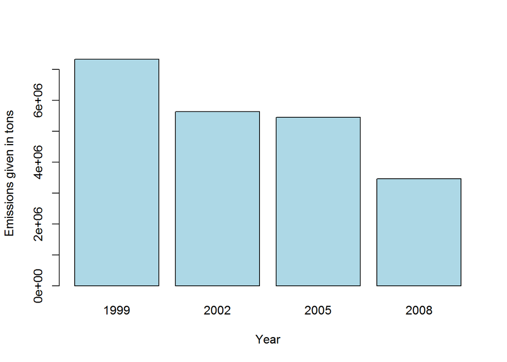

```r
totalEm <- tapply(data2$Emissions, data2$year, sum)
barplot(names.arg=names(totalEm),totalEm, xlab="Year", ylab="Emissions given in tons", pch=7, col="lightblue")
```

## Total emissions for Baltimor city, Maryland by years

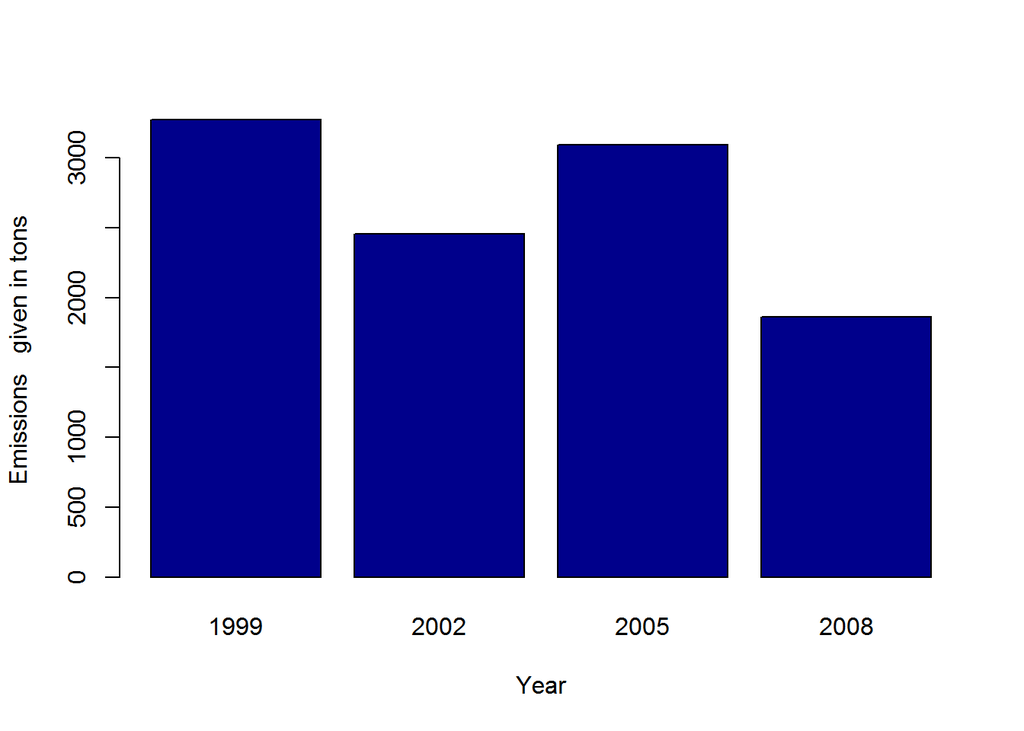

```r
 baltData <- subset(data2, data2$fips == "24510")
 baltEm <- tapply(baltData$Emissions, baltData$year, sum)
 barplot(names.arg =names(baltEm),baltEm, xlab="Year", ylab="Emissions   given in tons", pch=7, col="darkblue")
```

## Total emissions for Baltimor city, Maryland by years and types

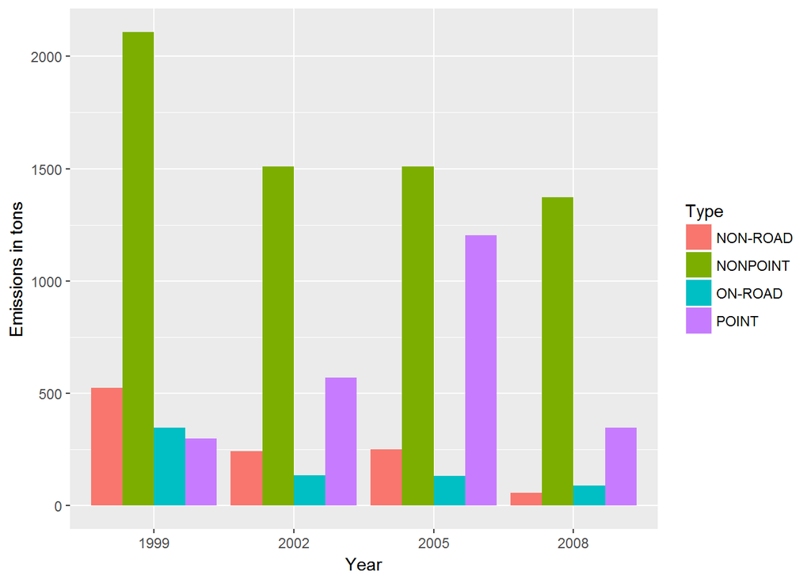

```r
library(ggplot2)
third<-aggregate(baltData$Emissions, by=list(baltData$type,baltData$year), sum)
#qplot(factor(Group.2), data=third, geom="bar", weight=x,fill=factor(Group.1))
ggplot(third, aes(factor(Group.2), fill=factor(Group.1), weight=x)) + geom_bar(position="dodge") + labs(x="Year", y="Emissions in tons", fill="Type")
```

```r
library(dplyr)
```

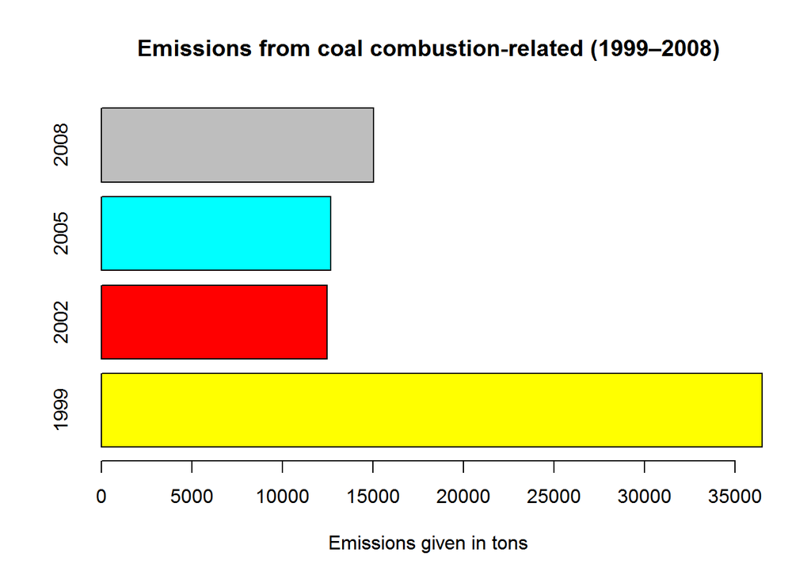

```r
forth_CSS <- data1[grepl( "comb", data1$SCC.Level.One, ignore.case = TRUE)& grepl("Comb", data1$SCC.Level.Four, ignore.case = TRUE), ]
forth_CSS <- forth_CSS$SCC
forthData <- data2[data2$SCC %in% forth_CSS,]
forth<-aggregate(forthData$Emissions, by=list(forthData$year), sum)
barplot(forth$x, names.arg = forth$Group.1, horiz = TRUE, col = forth$Group.1, xlab="Emissions given in tons", main="Emissions from coal combustion-related (1999–2008)")
```

## Emissions from motor vehicle sources changes from 1999–2008 in Baltimore City

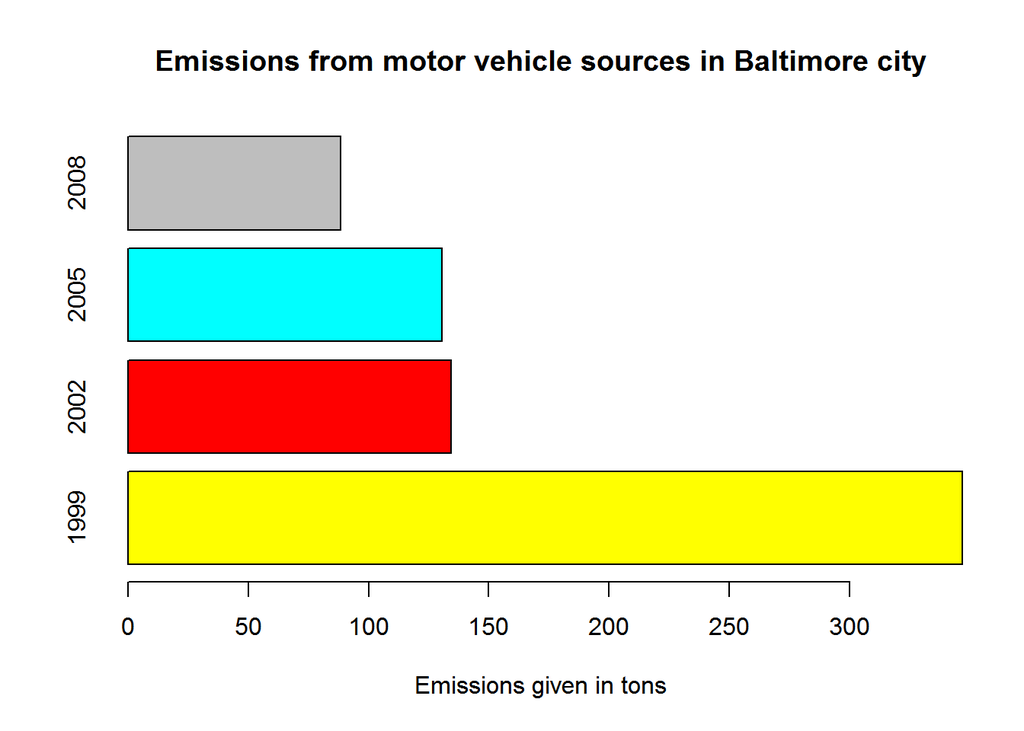

```r
fifth_CSS <- data1[grepl( "vehicle", data1$EI.Sector, ignore.case = TRUE), ]
fifth_CSS <- fifth_CSS$SCC
fifthData <- baltData[baltData$SCC %in% fifth_CSS,]
fifth<-aggregate(fifthData$Emissions, by=list(fifthData$year), sum)
barplot(fifth$x, names.arg = fifth$Group.1, horiz = TRUE, col = fifth$Group.1, xlab="Emissions given in tons", main="Emissions from motor vehicle sources in Baltimore city")
```

## Comparison emissions from motor vehicle sources in Baltimore City with emissions from motor vehicle sources in Los Angeles

[figure not shown]

```r
renames <- function(x) {
  if (x =="24510") {
    return ("Balttimore city")
  } else{
      return("Los Angelos")
  }
  }
baltLosData <- subset(data2, data2$fips == "24510" |data2$fips == "06037")
six_CSS <- data1[grepl( "vehicle", data1$EI.Sector, ignore.case = TRUE), ]
six_CSS <- six_CSS$SCC
sixData <- baltLosData[baltData$SCC %in% six_CSS,]
sixData <- mutate(sixData, name=sapply(sixData$fips, renames))
sixth<-aggregate(sixData$Emissions, by=list(sixData$year,sixData$name), sum)
ggplot(sixth, aes(factor(Group.1), fill=factor(Group.2), weight=x)) + geom_bar(position="dodge") + labs(x="Year", y="Emissions in tons", fill="City", title = "Comparison between Baltimore and Los Angelos")
```

[output not shown]